# Assignment 1 Q2

Refer to the dataset Census Income Data Set (also known as AdultUCI) Census Income Dataset at the UCI Machine Learning Repository with additional information on converting it to the Adult dataset for transaction processing at Adult Data Set information. Carry out association rule mining on this dataset by determining appropriate support and confidence levels and obtaining the top 10 rules.

The AdultUCI dataset that has been preprocessed for association rule mining is available within the “arules” package. Let us load the package and load the dataset as well

```r
library(arules)
data("Adult")
```

Let us first look at the structure of the Adult dataset.

```r
str(Adult)
```

```
Formal class 'transactions' [package "arules"] with 3 slots
  ..@ data       :Formal class 'ngCMatrix' [package "Matrix"] with 5 slots
  .. .. ..@ i       : int [1:612200] 1 10 25 32 35 50 59 61 63 65 ...
  .. .. ..@ p       : int [1:48843] 0 13 26 39 52 65 78 91 104 117 ...
  .. .. ..@ Dim     : int [1:2] 115 48842
  .. .. ..@ Dimnames:List of 2
  .. .. .. ..$ : NULL
  .. .. .. ..$ : NULL
  .. .. ..@ factors : list()
  ..@ itemInfo   :'data.frame': 115 obs. of  3 variables:
  .. ..$ labels   : chr [1:115] "age=Young" "age=Middle-aged" "age=Senior" "age=Old" ...
  .. ..$ variables: Factor w/ 13 levels "age","capital-gain",..: 1 1 1 1 13 13 13 13 13 13 ...
  .. ..$ levels   : Factor w/ 112 levels "10th","11th",..: 111 63 92 69 30 54 65 82 90 91 ...
  ..@ itemsetInfo:'data.frame': 48842 obs. of  1 variable:
  .. ..$ transactionID: chr [1:48842] "1" "2" "3" "4" ...
```

We can see that the dataset has been converted from a dataframe into a transactions dataset. Transactions datasets contain three slots: data, intemInfo, and itemsetInfo. From the R documentation on the transactions data class, data is the binary incidence matrix, itemInfo contains the item labels, and itemsetInfo is a dataframe with each row being a transaction.

We can view a summary of the Adult dataset using the summary function.

```r
summary(Adult)
```

```
transactions as itemMatrix in sparse format with
 48842 rows (elements/itemsets/transactions) and
 115 columns (items) and a density of 0.1089939

most frequent items:
           capital-loss=None            capital-gain=None native-country=United-States
                       46560                        44807                        43832
                  race=White            workclass=Private                      (Other)
                       41762                        33906                       401333

element (itemset/transaction) length distribution:
sizes
    9    10    11    12    13
   19   971  2067 15623 30162

   Min. 1st Qu.  Median    Mean 3rd Qu.    Max.
   9.00   12.00   13.00   12.53   13.00   13.00

includes extended item information - examples:
```

|  | labels | variables | levels |
| --- | --- | --- | --- |
| 1 | age=Young | age | Young |
| 2 | age=Middle-aged | age | Middle-aged |
| 3 | age=Senior | age | Senior |

```
includes extended transaction information - examples:
```

|  | transactionID |
| --- | --- |
| 1 | 1 |
| 2 | 2 |
| 3 | 3 |

We can view the transactions using the inspect function. Since there are over 40000 transactions recorded, we will only view the first 5.

```r
inspect(Adult[1:5])
```

```
    items                               transactionID
[1] {age=Middle-aged,
     workclass=State-gov,
     education=Bachelors,
     marital-status=Never-married,
     occupation=Adm-clerical,
     relationship=Not-in-family,
     race=White,
     sex=Male,
     capital-gain=Low,
     capital-loss=None,
     hours-per-week=Full-time,
     native-country=United-States,
     income=small}                                  1
[2] {age=Senior,
     workclass=Self-emp-not-inc,
     education=Bachelors,
     marital-status=Married-civ-spouse,
     occupation=Exec-managerial,
     relationship=Husband,
     race=White,
     sex=Male,
     capital-gain=None,
     capital-loss=None,
     hours-per-week=Part-time,
     native-country=United-States,
     income=small}                                  2
[3] {age=Middle-aged,
     workclass=Private,
     education=HS-grad,
     marital-status=Divorced,
     occupation=Handlers-cleaners,
     relationship=Not-in-family,
     race=White,
     sex=Male,
     capital-gain=None,
     capital-loss=None,
     hours-per-week=Full-time,
     native-country=United-States,
     income=small}                                  3
```

[output cut: 11 more lines]

```
     native-country=United-States,
     income=small}                                  4
[5] {age=Middle-aged,
     workclass=Private,
     education=Bachelors,
     marital-status=Married-civ-spouse,
     occupation=Prof-specialty,
     relationship=Wife,
     race=Black,
     sex=Female,
     capital-gain=None,
     capital-loss=None,
     hours-per-week=Full-time,
     native-country=Cuba,
     income=small}                                  5
```

Each transaction is this case is a combination of the different variables that we have in the original AdultUCI dataset.

We can also do some visualization of the item frequencies, to get an idea of the supports for rule mining. Let us look at items that have a support of at least 25% (0.25).

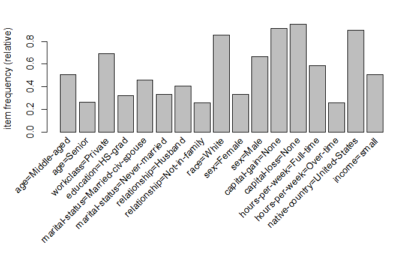

```r
itemFrequencyPlot(Adult, support = 0.25)
```

We can also look at the items that have the highest support. Let us look at the top 10 items.

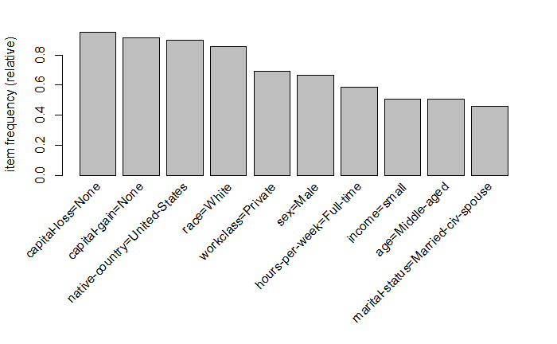

```r
itemFrequencyPlot(Adult, topN = 10)
```

To view the transaction matrix, we can use the image function. Since we have so many transactions, it is best to take a random sample in order create a meaningful visualization.

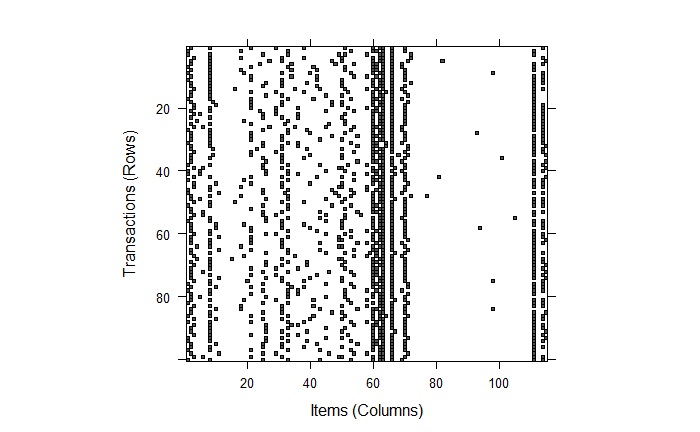

```r
image(sample(Adult, 100))
```

We have some very heavily populated columns. Most likely those correspond to the items that had very high support (no capital gains/losses, born in the US, White).

Now let us carry out association rule mining on this dataset. We will use the apriori function from the arules package. This function uses the apriori principle, that itemsets that are infrequent have subsets that are infrequent as well (which is a fairly obvious result from conditional probabilities). The goal will be to find itemsets that have high support (high number of appearances in the dataset), then identify the itemsets that have high confidence (high number of appearances for a subset within a set), and finally identify high lift (high frequency of one trait appearing given another trait appearing). Note that for each one of support, confidence, and lift, the apriori principle applies.

Let us start with the default settings (support = 0.1, confidence = 0.8).

```r
apriori(Adult)
```

```
Apriori

Parameter specification:
```

|  | confidence | minval | smax | arem | aval | originalSupport | maxtime | support | minlen | maxlen | target | ext |
| --- | --- | --- | --- | --- | --- | --- | --- | --- | --- | --- | --- | --- |
|  | 0.8 | 0.1 | 1 | none | FALSE | TRUE | 5 | 0.1 | 1 | 10 | rules | FALSE |

```
Algorithmic control:
```

|  | filter | tree | heap | memopt | load | sort | verbose |
| --- | --- | --- | --- | --- | --- | --- | --- |
|  | 0.1 | TRUE | TRUE | FALSE | TRUE | 2 | TRUE |

```
Absolute minimum support count: 4884

set item appearances ...[0 item(s)] done [0.02s].
set transactions ...[115 item(s), 48842 transaction(s)] done [0.07s].
sorting and recoding items ... [31 item(s)] done [0.01s].
creating transaction tree ... done [0.03s].
checking subsets of size 1 2 3 4 5 6 7 8 9 done [0.14s].
writing ... [6137 rule(s)] done [0.01s].
creating S4 object  ... done [0.02s].
set of 6137 rules
```

Using these settings we were able to create 6137 rules. Our goal for this assignment is to find the top 10 rules. Evidently the default settings are too lenient to discover only the top 10 rules.

We know based on our initial visualizations that the top 10 items all have a support higher than 0.4. Let us try that to see if it sufficiently limits the number of rules.

```r
apriori(Adult, parameter = list(support = 0.4, confidence = 0.8))
```

```
Apriori

Parameter specification:
```

|  | confidence | minval | smax | arem | aval | originalSupport | maxtime | support | minlen | maxlen | target | ext |
| --- | --- | --- | --- | --- | --- | --- | --- | --- | --- | --- | --- | --- |
|  | 0.8 | 0.1 | 1 | none | FALSE | TRUE | 5 | 0.4 | 1 | 10 | rules | FALSE |

```
Algorithmic control:
```

|  | filter | tree | heap | memopt | load | sort | verbose |
| --- | --- | --- | --- | --- | --- | --- | --- |
|  | 0.1 | TRUE | TRUE | FALSE | TRUE | 2 | TRUE |

```
Absolute minimum support count: 19536

set item appearances ...[0 item(s)] done [0.01s].
set transactions ...[115 item(s), 48842 transaction(s)] done [0.06s].
sorting and recoding items ... [11 item(s)] done [0.01s].
creating transaction tree ... done [0.02s].
checking subsets of size 1 2 3 4 5 done [0.03s].
writing ... [169 rule(s)] done [0.01s].
creating S4 object  ... done [0.03s].
set of 169 rules
```

This still gives us 169 rules. After playing with the parameters, a support of 0.8 combined with a confidence of 0.89 gives us exactly 10 rules.

```r
top10rules = apriori(Adult, parameter = list(support = 0.8, confidence = 0.89))
```

```
Apriori

Parameter specification:
```

|  | confidence | minval | smax | arem | aval | originalSupport | maxtime | support | minlen | maxlen | target | ext |
| --- | --- | --- | --- | --- | --- | --- | --- | --- | --- | --- | --- | --- |
|  | 0.89 | 0.1 | 1 | none | FALSE | TRUE | 5 | 0.8 | 1 | 10 | rules | FALSE |

```
Algorithmic control:
```

|  | filter | tree | heap | memopt | load | sort | verbose |
| --- | --- | --- | --- | --- | --- | --- | --- |
|  | 0.1 | TRUE | TRUE | FALSE | TRUE | 2 | TRUE |

```
Absolute minimum support count: 39073

set item appearances ...[0 item(s)] done [0.01s].
set transactions ...[115 item(s), 48842 transaction(s)] done [0.06s].
sorting and recoding items ... [4 item(s)] done [0.02s].
creating transaction tree ... done [0.02s].
checking subsets of size 1 2 3 done [0.02s].
writing ... [10 rule(s)] done [0.00s].
creating S4 object  ... done [0.02s].
```

Let us asses our model performance.

```r
summary(top10rules)
```

```
set of 10 rules

rule length distribution (lhs + rhs):sizes
1 2
3 7

   Min. 1st Qu.  Median    Mean 3rd Qu.    Max.
   1.00    1.25    2.00    1.70    2.00    2.00

summary of quality measures:
    support         confidence          lift            count
 Min.   :0.8137   Min.   :0.8960   Min.   :0.9956   Min.   :39742
 1st Qu.:0.8302   1st Qu.:0.9014   1st Qu.:0.9983   1st Qu.:40548
 Median :0.8628   Median :0.9166   Median :0.9988   Median :42139
 Mean   :0.8677   Mean   :0.9243   Mean   :0.9985   Mean   :42379
 3rd Qu.:0.8907   3rd Qu.:0.9510   3rd Qu.:0.9998   3rd Qu.:43505
 Max.   :0.9533   Max.   :0.9533   Max.   :1.0000   Max.   :46560

mining info:
```

|  | data | ntransactions | support | confidence |
| --- | --- | --- | --- | --- |
|  | Adult | 48842 | 0.8 | 0.89 |

Our model has high support, high confidence, however the lift we see is bounded at 1. This means we did not find rules that allow us to determine increases in likelihood of one trait given some other trait.

Let us take a look at the top 10 rules, sorted by lift.

```r
inspect(sort(top10rules, by = "lift"))
```

|  | lhs |  | rhs | support | confidence | lift | count |
| --- | --- | --- | --- | --- | --- | --- | --- |
| [1] | {} | => | {native-country=United-States} | 0.8974243 | 0.8974243 | 1.0000000 | 43832 |
| [2] | {} | => | {capital-gain=None} | 0.9173867 | 0.9173867 | 1.0000000 | 44807 |
| [3] | {} | => | {capital-loss=None} | 0.9532779 | 0.9532779 | 1.0000000 | 46560 |
| [4] | {capital-loss=None} | => | {native-country=United-States} | 0.8548380 | 0.8967354 | 0.9992323 | 41752 |
| [5] | {native-country=United-States} | => | {capital-loss=None} | 0.8548380 | 0.9525461 | 0.9992323 | 41752 |
| [6] | {capital-gain=None} | => | {native-country=United-States} | 0.8219565 | 0.8959761 | 0.9983862 | 40146 |
| [7] | {native-country=United-States} | => | {capital-gain=None} | 0.8219565 | 0.9159062 | 0.9983862 | 40146 |
| [8] | {race=White} | => | {capital-loss=None} | 0.8136849 | 0.9516307 | 0.9982720 | 39742 |
| [9] | {capital-loss=None} | => | {capital-gain=None} | 0.8706646 | 0.9133376 | 0.9955863 | 42525 |
| [10] | {capital-gain=None} | => | {capital-loss=None} | 0.8706646 | 0.9490705 | 0.9955863 | 42525 |

Here we can see that the top 10 rules all consist of the traits no capital gains/losses, United States natives, and being White. Since the traits of no capital gains/losses and being an US native are so dominant, it would be worthwhile to remove those variables (capital gains/losses, native country) entirely, to see which other association rules become important.